# Data 413: Test 1

Frankie Tyndall

2022-07-14

## 1a: Is U an atomic vector or a list ?

```r
U <- c("Maine", "Texas", "Delaware", "Oregon", "Utah", "Vermont", "Ohio")
U
```

```
## [1] "Maine"    "Texas"    "Delaware" "Oregon"   "Utah"     "Vermont"  "Ohio"
```

All objects of U are character strings so U is an atomic vector

## 1b: Use and show R code that will extract the elements “Maine” and “Vermont”

```r
U[c(1,6)]
```

```
## [1] "Maine"   "Vermont"
```

## 1C: Use and show R code that will extract all elements except “Texas”

```r
U[-2]
```

```
## [1] "Maine"    "Delaware" "Oregon"   "Utah"     "Vermont"  "Ohio"
```

## 1D: Use and show R code that will produce length of U

```r
length(U)
```

```
## [1] 7
```

## 2A: Is V an atomic vector or a list ?

```r
V = list("Chicago", k = list(2, 6, 18, 24), FALSE, 13, 1.3,  y = 1:10)
V
```

```
## [[1]]
## [1] "Chicago"
##
## $k
## $k[[1]]
## [1] 2
##
## $k[[2]]
## [1] 6
##
## $k[[3]]
## [1] 18
##
## $k[[4]]
## [1] 24
##
##
## [[3]]
## [1] FALSE
##
## [[4]]
## [1] 13
##
## [[5]]
## [1] 1.3
##
## $y
##  [1]  1  2  3  4  5  6  7  8  9 10
```

V is a list because all the objects in V are not of the same type. List V has a character string, integers, doubles, and a logical entry.

## 2B: Use and show R code that will extract the 5th element of V

```r
V[[5]]
```

```
## [1] 1.3
```

## 2C: If the vector V is a list, use and show R code to identify the type of each object in V.

```r
str(V)
```

```
## List of 6
##  $  : chr "Chicago"
##  $ k:List of 4
##   ..$ : num 2
##   ..$ : num 6
##   ..$ : num 18
##   ..$ : num 24
##  $  : logi FALSE
##  $  : num 13
##  $  : num 1.3
##  $ y: int [1:10] 1 2 3 4 5 6 7 8 9 10
```

## The Testscore Tibble

```r
tribble( ~John,    ~Raymond,    ~Martha,  ~Alice,  ~Juan,
              86,    77,            81,     88,      90,
              79,    78,            85,     81,      78,
              76,    75,            88,     94,      81,
              84,    90,            71,     84,      89,
              100,   80,            93,     85,      84,
              90,    73,            70,     88,      93,

         ) -> TestScores

TestScores
```

```
## # A tibble: 6 × 5
##    John Raymond Martha Alice  Juan
##   <dbl>   <dbl>  <dbl> <dbl> <dbl>
## 1    86      77     81    88    90
## 2    79      78     85    81    78
## 3    76      75     88    94    81
## 4    84      90     71    84    89
## 5   100      80     93    85    84
## 6    90      73     70    88    93
```

## 3a: Use and show R code (a map function) to find the median for each column.

```r
map_dbl(TestScores, median)
```

```
##    John Raymond  Martha   Alice    Juan
##    85.0    77.5    83.0    86.5    86.5
```

## 3b: Use and show R code (a map function) to find the cube root of each column element

```r
TestScores %>%
  map(~. ^(0.33333333333))
```

```
## $John
## [1] 4.414005 4.290840 4.235824 4.379519 4.641589 4.481405
##
## $Raymond
## [1] 4.254321 4.272659 4.217163 4.481405 4.308869 4.179339
##
## $Martha
## [1] 4.326749 4.396830 4.447960 4.140818 4.530655 4.121285
##
## $Alice
## [1] 4.447960 4.326749 4.546836 4.379519 4.396830 4.447960
##
## $Juan
## [1] 4.481405 4.272659 4.326749 4.464745 4.379519 4.530655
```

## 3c: Use and show R code (a map function) to convert each column value to 0

```r
convert_zero <- TestScores %>%
  map(~. ^(0)) %>%
  replace(1:5, 0)

convert_zero
```

```
## $John
## [1] 0
##
## $Raymond
## [1] 0
##
## $Martha
## [1] 0
##
## $Alice
## [1] 0
##
## $Juan
## [1] 0
```

## 4 Use and show R code, as demonstrated in class to produce the following matrix

```r
A <- matrix(c(- 4, -9, -16, -25,
              - 9, -16, -25, -36,
              - 16, -25, -36, -49), ncol = 4, byrow = TRUE)
A
```

```
##      [,1] [,2] [,3] [,4]
## [1,]   -4   -9  -16  -25
## [2,]   -9  -16  -25  -36
## [3,]  -16  -25  -36  -49
```

## 5A: Show and use a census API key that gives you access to the ACS data. Do not use my API key, use and show your own key.

```r
census_api_key("2398180071d436d7b99c3fed84a8602682576343")
```

```
## To install your API key for use in future sessions, run this function with `install = TRUE`.
```

```r
install = TRUE

v15 <- load_variables(2015, "acs5", cache = TRUE)
view(v15)
```

## 5B: Using ACS census data from 2015, show and use R code to do the following to produce a tibble that shows the median income estimates and the margin of errors for white males ages 35 - 44 in the counties of California. The required variable code starts with the characters BO1OO1. Use the table to find the other characters.

```r
Cal <- get_acs(geography = "county",
               variables = c(medincome = "B01001A_011"),
               state = " California",
               year = 2015)
Cal
```

```
## # A tibble: 58 × 5
##    GEOID NAME                            variable  estimate   moe
##    <chr> <chr>                           <chr>        <dbl> <dbl>
##  1 06001 Alameda County, California      medincome    51644   667
##  2 06003 Alpine County, California       medincome       50    26
##  3 06005 Amador County, California       medincome     1809    72
##  4 06007 Butte County, California        medincome     9962   128
##  5 06009 Calaveras County, California    medincome     1927    74
##  6 06011 Colusa County, California       medincome     1147    79
##  7 06013 Contra Costa County, California medincome    42756   605
##  8 06015 Del Norte County, California    medincome     1629    90
##  9 06017 El Dorado County, California    medincome     8609   141
## 10 06019 Fresno County, California       medincome    34979   714
## # … with 48 more rows
```

## 5c: Use dplyr functions to change your table of part a so that it reflects estimates that are greater than $30,000 dollars and list the estimates in descending order.

```r
estimate_greater <- Cal %>%
  arrange(desc(estimate)) %>%
  filter(estimate > 30000)

estimate_greater
```

```
## # A tibble: 13 × 5
##    GEOID NAME                              variable  estimate   moe
##    <chr> <chr>                             <chr>        <dbl> <dbl>
##  1 06037 Los Angeles County, California    medincome   375435  2332
##  2 06073 San Diego County, California      medincome   150891  1008
##  3 06059 Orange County, California         medincome   126819  1152
##  4 06065 Riverside County, California      medincome    92346  1004
##  5 06071 San Bernardino County, California medincome    80925  1160
##  6 06085 Santa Clara County, California    medincome    63036   879
##  7 06067 Sacramento County, California     medincome    56066   553
##  8 06001 Alameda County, California        medincome    51644   667
##  9 06013 Contra Costa County, California   medincome    42756   605
## 10 06075 San Francisco County, California  medincome    42307   542
## 11 06029 Kern County, California           medincome    42121   575
## 12 06111 Ventura County, California        medincome    41155   557
## 13 06019 Fresno County, California         medincome    34979   714
```

## 5D: Use and show ggplot R coding to produce a scatter plot that features x = natural log of moe plotted against y = natural log of estimate. Does your plot suggest a linear relationship between the varibles ? If so, what general trend can be inferred? (Use the full data table that you generated for part b)

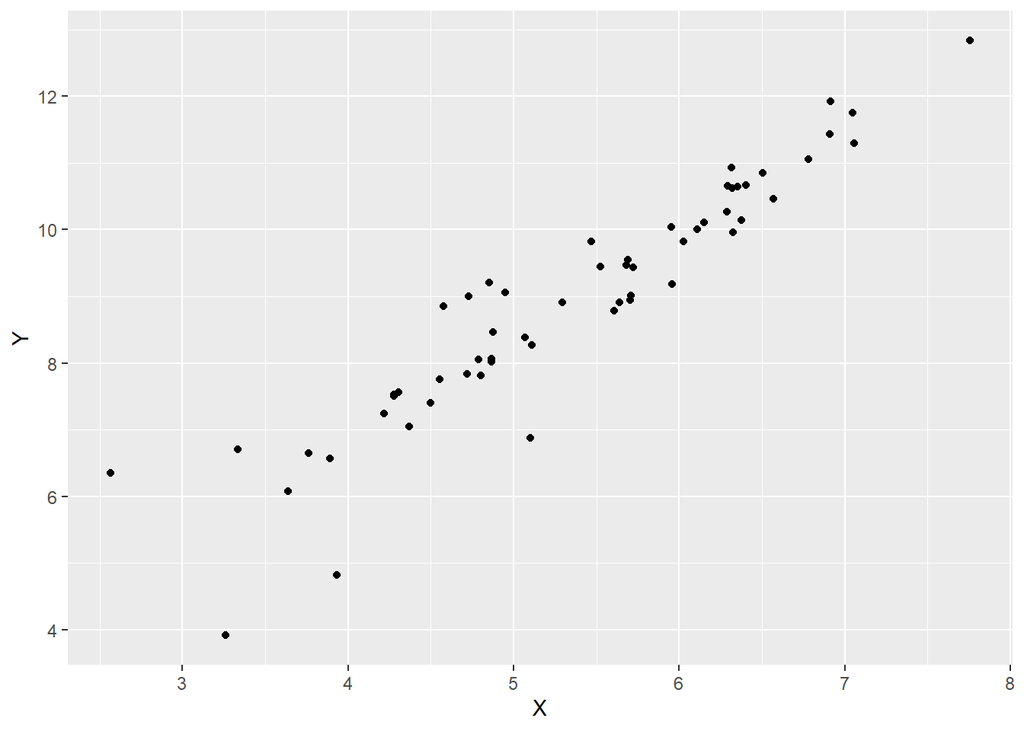

```r
regression <- Cal

regression['X'] <- NULL
regression['Y'] <- NULL

regression['X'] <- log(regression$moe)
regression['Y'] <- log(regression$estimate)

ggplot(regression, aes(x=X, y=Y)) + geom_point()
```

The scatterpplot shows that there is a linear correlation between the X and Y variable. The trend has a strong positive linear relationship as the points form a straight line.

## Use and show R code that will produce the following graph for the data generated in part c

```r
estimate_greater <- Cal %>%
  arrange(desc(estimate)) %>%
  filter(estimate > 30000)

estimate_greater
```

```
## # A tibble: 13 × 5
##    GEOID NAME                              variable  estimate   moe
##    <chr> <chr>                             <chr>        <dbl> <dbl>
##  1 06037 Los Angeles County, California    medincome   375435  2332
##  2 06073 San Diego County, California      medincome   150891  1008
##  3 06059 Orange County, California         medincome   126819  1152
##  4 06065 Riverside County, California      medincome    92346  1004
##  5 06071 San Bernardino County, California medincome    80925  1160
##  6 06085 Santa Clara County, California    medincome    63036   879
##  7 06067 Sacramento County, California     medincome    56066   553
##  8 06001 Alameda County, California        medincome    51644   667
##  9 06013 Contra Costa County, California   medincome    42756   605
## 10 06075 San Francisco County, California  medincome    42307   542
## 11 06029 Kern County, California           medincome    42121   575
## 12 06111 Ventura County, California        medincome    41155   557
## 13 06019 Fresno County, California         medincome    34979   714
```

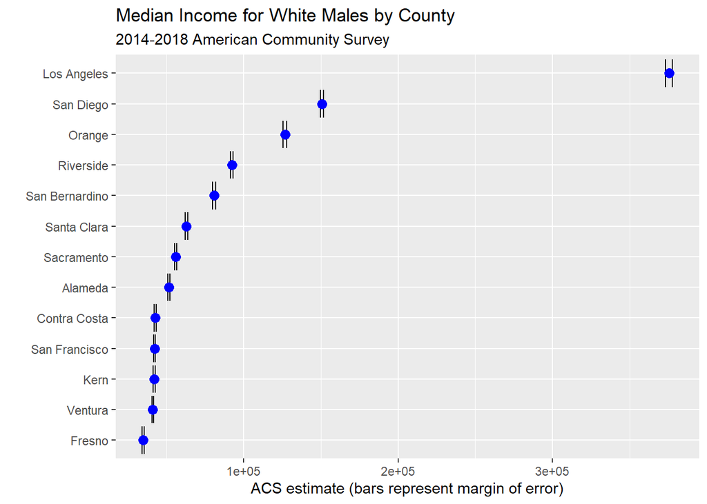

```r
estimate_greater %>%
  mutate(NAME = gsub(" County, California", "", NAME)) %>%
  ggplot(aes(x = estimate, y = reorder(NAME, estimate))) +
  geom_errorbarh(aes(xmin = estimate - moe, xmax = estimate + moe)) +
  geom_point(color = "blue", size = 3) +
  labs(title = "Median Income for White Males by County",
       subtitle = "2014-2018 American Community Survey",
       y = "",
       x = "ACS estimate (bars represent margin of error)")
```

## Provided below is the famous poem,“ Stopping by the Wood On a Snowy Evening” by Robert Frost.

```r
text56 <- c("Whose woods these are I think I know.",
"His house is in the village though",
"He will not see me stopping here",
"To watch his woods fill up with snow.",
"My little horse must think it queer",
"To stop without a farmhouse near",
"Between the woods and frozen lake",
"The darkest evening of the year.",
"He gives his harness bells a shake",
"To ask if there is some mistake.",
"The only other sound’s the sweep",
"Of easy wind and downy flake.",
"The woods are lovely, dark and deep,",
"But I have promises to keep,",
"And miles to go before I sleep",
"And miles to go before I sleep"
)
text56
```

```
##  [1] "Whose woods these are I think I know."
##  [2] "His house is in the village though"
##  [3] "He will not see me stopping here"
##  [4] "To watch his woods fill up with snow."
##  [5] "My little horse must think it queer"
##  [6] "To stop without a farmhouse near"
##  [7] "Between the woods and frozen lake"
##  [8] "The darkest evening of the year."
##  [9] "He gives his harness bells a shake"
## [10] "To ask if there is some mistake."
## [11] "The only other sound’s the sweep"
## [12] "Of easy wind and downy flake."
## [13] "The woods are lovely, dark and deep,"
## [14] "But I have promises to keep,"
## [15] "And miles to go before I sleep"
## [16] "And miles to go before I sleep"
```

## 6A: Create a tibble

```r
text56_tibble <- tibble(line = 241:256, text56 = text56)
text56_tibble
```

```
## # A tibble: 16 × 2
##     line text56
##    <int> <chr>
##  1   241 Whose woods these are I think I know.
##  2   242 His house is in the village though
##  3   243 He will not see me stopping here
##  4   244 To watch his woods fill up with snow.
##  5   245 My little horse must think it queer
##  6   246 To stop without a farmhouse near
##  7   247 Between the woods and frozen lake
##  8   248 The darkest evening of the year.
##  9   249 He gives his harness bells a shake
## 10   250 To ask if there is some mistake.
## 11   251 The only other sound’s the sweep
## 12   252 Of easy wind and downy flake.
## 13   253 The woods are lovely, dark and deep,
## 14   254 But I have promises to keep,
## 15   255 And miles to go before I sleep
## 16   256 And miles to go before I sleep
```

## 6B: find line locations of words

```r
text56_tibble %>% unnest_tokens(word, text56) -> tibble11
tibble11
```

```
## # A tibble: 108 × 2
##     line word
##    <int> <chr>
##  1   241 whose
##  2   241 woods
##  3   241 these
##  4   241 are
##  5   241 i
##  6   241 think
##  7   241 i
##  8   241 know
##  9   242 his
## 10   242 house
## # … with 98 more rows
```

## 6C: produce a word frequency table

```r
tibble11%>%
  count(word, sort =TRUE)
```

```
## # A tibble: 74 × 2
##    word       n
##    <chr>  <int>
##  1 the        7
##  2 to         6
##  3 and        5
##  4 i          5
##  5 woods      4
##  6 his        3
##  7 a          2
##  8 are        2
##  9 before     2
## 10 go         2
## # … with 64 more rows
```

## 6d: Create a bar graph data visualization plot that will also display word frequency trends.

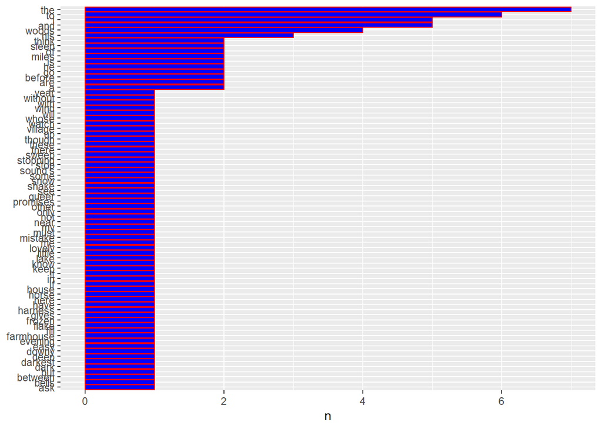

```r
tibble11%>%
  count(word, sort =TRUE) %>%
  mutate(word = reorder(word, n)) %>%
  ggplot(aes(n, word)) +
  geom_col(fill = "blue", color = "red") +
  labs(y = NULL)
```

## 7: Now using the same body of text found in Problem 6, use and show R code to create a word cloud. You can use the coding and methods that were illustrated in class or you can use alternate coding of your choice to create the word cloud.

```r
text76 <- readLines(file.choose("evening"))
text76
```

```
##  [1] "Whose woods these are I think I know."
##  [2] "His house is in the village though;"
##  [3] "He will not see me stopping here"
##  [4] "To watch his woods fill up with snow."
##  [5] "My little horse must think it queer"
##  [6] "To stop without a farmhouse near"
##  [7] "Between the woods and frozen lake"
##  [8] "The darkest evening of the year."
##  [9] "He gives his harness bells a shake"
## [10] "To ask if there is some mistake."
## [11] "The only other sound’s the sweep"
## [12] "Of easy wind and downy flake."
## [13] "The woods are lovely, dark and deep,"
## [14] "But I have promises to keep,"
## [15] "And miles to go before I sleep,"
## [16] "And miles to go before I sleep."
```

```r
docs4 <- Corpus(VectorSource(text76))


inspect(docs4)
```

```
## <<SimpleCorpus>>
## Metadata:  corpus specific: 1, document level (indexed): 0
## Content:  documents: 16
##
##  [1] Whose woods these are I think I know. His house is in the village though;
##  [3] He will not see me stopping here      To watch his woods fill up with snow.
##  [5] My little horse must think it queer   To stop without a farmhouse near
##  [7] Between the woods and frozen lake     The darkest evening of the year.
##  [9] He gives his harness bells a shake    To ask if there is some mistake.
## [11] The only other sound’s the sweep      Of easy wind and downy flake.
## [13] The woods are lovely, dark and deep,  But I have promises to keep,
## [15] And miles to go before I sleep,       And miles to go before I sleep.
```

```r
toSpace <- content_transformer(function (x , pattern ) gsub(pattern, " ", x))
docs4 <- tm_map(docs4, toSpace, "/")
docs4 <- tm_map(docs4, toSpace, "@")
docs4 <- tm_map(docs4, toSpace, "\\|")
docs4 <- tm_map(docs4, content_transformer(tolower))
# Remove numbers
docs4 <- tm_map(docs4, removeNumbers)
# Remove english common stopwords
docs4 <- tm_map(docs4, removeWords, stopwords("english"))
# Remove your own stop word
# specify your stopwords as a character vector
docs4 <- tm_map(docs4, removeWords, c("blabla1", "blabla2"))
# Remove punctuations
docs4 <- tm_map(docs4, removePunctuation)
# Eliminate extra white spaces
docs4 <- tm_map(docs4, stripWhitespace)
dtm <- TermDocumentMatrix(docs4)
m <- as.matrix(dtm)
v <- sort(rowSums(m),decreasing=TRUE)
d <- data.frame(word = names(v),freq=v)
head(d, 10)
```

```
##            word freq
## woods     woods    4
## think     think    2
## miles     miles    2
## sleep     sleep    2
## know       know    1
## whose     whose    1
## house     house    1
## though   though    1
## village village    1
## see         see    1
```

[figure not shown]

```r
set.seed(1234)
wordcloud(words = d$word, freq = d$freq, min.freq = 1,
          max.words=200, random.order=FALSE, rot.per=0.35,
          colors=brewer.pal(8, "PuBuGn"))
```

## 8 Go to the link https://www.imdb.com/list/ls096735829 and use Selector Gadget ,as demonstrated in class to collect data specific to the movie names, the directors of the movies, the movie ratings, and the running times of the movies. Your code should produce the final resulting table given below.Hint: (you may have to first create a data frame, and then convert the data frame to the tibble shown below.

```r
Link <- "https://www.imdb.com/list/ls096735829"
page = read_html(Link)
Movies2020 = page%>% html_nodes(".lister-item-header a")%>%
  html_text()
Movies2020
```

```
##  [1] "Weathering with You"
##  [2] "The Empty Man"
##  [3] "Monsters of Man"
##  [4] "Songbird"
##  [5] "Tesla"
##  [6] "Underwater"
##  [7] "Greenland"
##  [8] "Possessor"
##  [9] "Tenet"
## [10] "The Phenomenon"
## [11] "Synchronic"
## [12] "Trump Card"
## [13] "Deep Blue Sea 3"
## [14] "The Vast of Night"
## [15] "Vivarium"
```

[output cut: 32 more lines]

```r
Link <- "https://www.imdb.com/list/ls096735829"
page = read_html(Link)
Directors2020 = page%>% html_nodes(".text-muted a:nth-child(1)")%>%
  html_text()
Directors2020
```

```
##  [1] "Makoto Shinkai"         "David Prior"            "Mark Toia"
##  [4] "Adam Mason"             "Michael Almereyda"      "William Eubank"
##  [7] "Ric Roman Waugh"        "Brandon Cronenberg"     "Christopher Nolan"
## [10] "James Fox"              "Justin Benson"          "Dinesh D'Souza"
## [13] "John Pogue"             "Andrew Patterson"       "Lorcan Finnegan"
## [16] "Carl Strathie"          "Sam Hargrave"           "Takashi Yamazaki"
## [19] "Ninian Doff"            "Genndy Tartakovsky"     "Lech Majewski"
## [22] "Patrice Laliberté"      "Adil El Arbi"           "Eshom Nelms"
## [25] "Oz Perkins"             "Guy Ritchie"            "Matt Poitras"
## [28] "Jeff Baena"             "Sang-ho Yeon"           "Egor Abramenko"
## [31] "Jake Kasdan"            "Yu Yang"                "Galder Gaztelu-Urrutia"
## [34] "Brett Pierce"           "Colin Minihan"          "Leigh Whannell"
## [37] "Takeru Nakajima"        "Richard Stanley"        "Craig Zobel"
## [40] "Severin Fiala"          "Ant Timpson"            "Jeff Fowler"
## [43] "Gille Klabin"           "Dave Wilson"            "Andrew Traucki"
## [46] "Motonori Sakakibara"    "Will Becher"
```

```r
Link <- "https://www.imdb.com/list/ls096735829"
page = read_html(Link)
Ratings2020 = page%>% html_nodes(".ipl-rating-star.small .ipl-rating-star__rating")%>%
  html_text()
Ratings2020
```

```
##  [1] "7.5" "6.2" "5.4" "4.7" "5.1" "5.8" "6.4" "6.5" "7.3" "7.4" "6.2" "5.2"
## [13] "4.7" "6.7" "5.8" "5.3" "6.7" "6.5" "6.2" "8.4" "4.5" "6"   "6.5" "5.9"
## [25] "5.4" "7.8" "3.8" "5.9" "5.5" "6.4" "6.7" "7.4" "7"   "5.8" "5.7" "7.1"
## [37] "6.5" "6.1" "6.5" "6"   "6"   "6.5" "6.1" "5.7" "4.5" "5.7" "6.8"
```

```r
Link <- "https://www.imdb.com/list/ls096735829"
page = read_html(Link)
Runtime2020 = page%>% html_nodes(".runtime")%>%
  html_text()
Runtime2020
```

```
##  [1] "112 min" "137 min" "131 min" "84 min"  "102 min" "95 min"  "119 min"
##  [8] "103 min" "150 min" "100 min" "102 min" "103 min" "100 min" "91 min"
## [15] "97 min"  "97 min"  "116 min" "103 min" "87 min"  "85 min"  "126 min"
## [22] "83 min"  "124 min" "100 min" "87 min"  "113 min" "95 min"  "103 min"
## [29] "116 min" "113 min" "123 min" "110 min" "94 min"  "95 min"  "98 min"
## [36] "124 min" "74 min"  "111 min" "90 min"  "108 min" "96 min"  "99 min"
## [43] "87 min"  "109 min" "98 min"  "98 min"  "86 min"
```

```r
moviesdataframe = data.frame(Movies2020,Directors2020, Ratings2020,Runtime2020)

as_tibble(moviesdataframe)
```

```
## # A tibble: 47 × 4
##    Movies2020          Directors2020      Ratings2020 Runtime2020
##    <chr>               <chr>              <chr>       <chr>
##  1 Weathering with You Makoto Shinkai     7.5         112 min
##  2 The Empty Man       David Prior        6.2         137 min
##  3 Monsters of Man     Mark Toia          5.4         131 min
##  4 Songbird            Adam Mason         4.7         84 min
##  5 Tesla               Michael Almereyda  5.1         102 min
##  6 Underwater          William Eubank     5.8         95 min
##  7 Greenland           Ric Roman Waugh    6.4         119 min
##  8 Possessor           Brandon Cronenberg 6.5         103 min
##  9 Tenet               Christopher Nolan  7.3         150 min
## 10 The Phenomenon      James Fox          7.4         100 min
## # … with 37 more rows
```